# Homicides in the U.S.A.

# Introduction

This project looks at homicides committed in the United States from 1980 onwards. The analysis is centered around different age-groups and looks at certain sub-populations. It also looks at the evolution of crime levels over time. The random forest model tries to predict the race of perpetrators. The linear model tries to predict the age of the perpetrator based on victim age. The data was downloaded from Kaggle.

# About the Dataset

The dataset includes 638k rows and 24 columns. It contains extensive information about homicides such as location, type of crime, murder weapon, relationship between perpetrator and victim as well as age and race information for both victim and perpetrator. The columns which the analysis focuses on are qualitative in nature with the exception of Age.

The dataframe was reduced to 420k rows and 16 columns by removing missing data in certain cells and by removing columns that contained information that was not pertinent to the analysis. The columns Agency_Code, Agency_Name and Agency_Type were dropped as they provided no information for the projections of interest. The rows were reduced because of missing or incomplete data.

# Steps Take to Clean Data

Before proceeding with any analysis the Victim_Age, Perpetrator_Age, and Crime_Type columns were cleand. This was done by using the filter() function to retain all the rows within those columns that met the necessary requirements. Thus, Victim ages equal to 998, Perpetrator ages that were blank or less than 4, and Crime type equal to Manslaughter by Negligence were filtered out.

Within the Relationship column, “Boyfriend” and “Girlfriend” were reclassified to “Boyfriend/Girlfriend”, “Employee” and “Employer” to “Colleague”, “Common-Law_Husband” to “Husband”, and “Common-Law_Wife” to “Wife”. This was done by using the $ command to select the Relationship column within the dataset. Then, subsetting was applied by bracket notation to select the categories to change within Relationship. From there, the new categories were applied to the selected categories by vectorization.

Next, the Weapon column was cleaned with the same procedure that was applied to the Relationship column. This allowed to reclassify “Gun”, “Handgun”, “Rifle”, and “Shotgun” to “Firearm”, and “Suffocation” and “Strangulation” to “Suffocation/Strangulation”.

Lastly, new columns of Perpetrator_Age_Group, Victim_Age_Group, and Seasons were created. To create a new column, first a categorize function which includes a single multipath if statement was defined. The if statement makes a logical comparison between the values from the selected column and what is expected by testing for a condition. It only returns a character string when the condition is True. Then, the sapply function was used with the selected column from the dataset and the categorize function as the arguments. The output from sapply was assigned to the new column, which was created by using the $ command on the dataset with the name of the new column. This procedure was used to create the other two new columns.

# Time series of murders

Here are the first 5 years of homicides.

Evolution of murders over time

| Year | Murders_each_year |
| --- | --- |
| 1980 | 15910 |
| 1981 | 15111 |
| 1982 | 14415 |
| 1983 | 13795 |
| 1984 | 12545 |

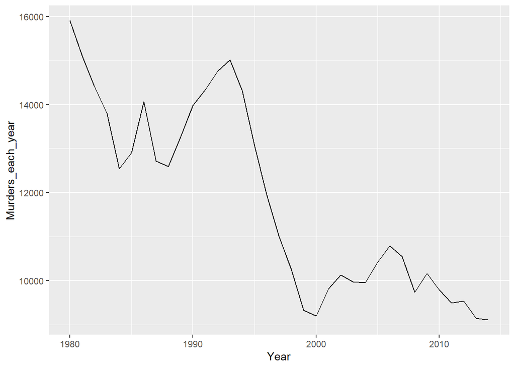

## Overview of timeseries

As seen, there is a very sharp drop of murders committed starting in the early 1990’s. The worst was at the beginning of the 80’s and early 90’s

**Incidents by State**

This graph showcases total incidents by state. As expected, the state with the highest population has the most murders. Further into the analysis, data from California was used as it provided a solid foundation for the linear model.

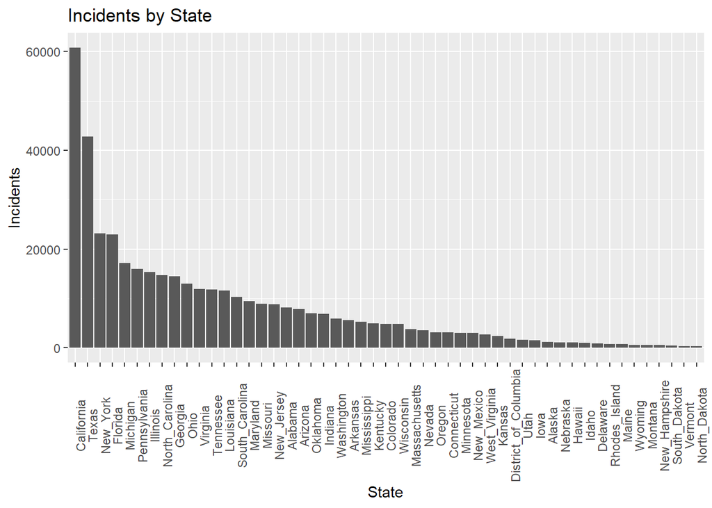

# Analysis of Victim vs Perp Sex

**Males vs Females**

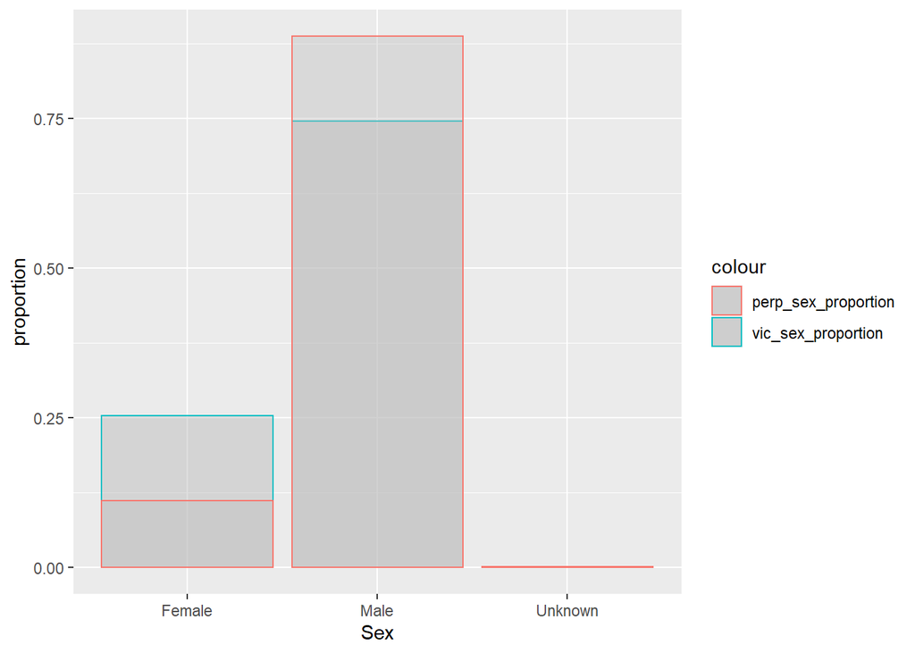

# Analysis of Perpetrators by Age Groups

## Adults (18+) vs. Underage (under 18)

Adults vs. Underage

| Perp_Age_Group | N_homicides | Percent_homicides |
| --- | --- | --- |
| Adults | 381302 | 0.922903 |
| Underage | 31853 | 0.077097 |

**Observations of Homicides Committed by Adults vs. Underage**

1. Adults perpetrators committed a total of 381302 homicides, which is about 92%.
2. Underage perpetrators committed a total of 31853 homicides, which is about 8%.

## Breakdown of Age Groups

Breakdown by Perpetrator Age Group

| Perpetrator_Age_Group | Count | Proportion |
| --- | --- | --- |
| 20-29 | 130738 | 0.3164381 |
| 30-39 | 91380 | 0.2211761 |
| 40-49 | 55791 | 0.1350365 |
| 10-19 | 48607 | 0.1176483 |
| 50-59 | 30576 | 0.0740061 |
| 9 and under | 21702 | 0.0525275 |
| 60-69 | 16123 | 0.0390241 |
| 70-79 | 9414 | 0.0227856 |
| 80-89 | 4515 | 0.0109281 |
| 90 and over | 4309 | 0.0104295 |

**Frequency of Homicides Committed within Age Groups**

## Elderly (90+) Perpetrators - Weapons of Choice

Weapons of Choice by Elderly Perpetrators

| Perpetrator_Age_Group | Weapon | Num_Weapons | Proportion |
| --- | --- | --- | --- |
| 90 and over | Firearm | 2043 | 0.4741239 |
| 90 and over | Blunt_Object | 891 | 0.2067765 |
| 90 and over | Knife | 631 | 0.1464377 |
| 90 and over | Unknown | 476 | 0.1104665 |
| 90 and over | Suffocation/Strangulation | 124 | 0.0287770 |
| 90 and over | Fire | 83 | 0.0192620 |
| 90 and over | Drugs | 30 | 0.0069622 |
| 90 and over | Drowning | 12 | 0.0027849 |
| 90 and over | Poison | 12 | 0.0027849 |
| 90 and over | Explosives | 4 | 0.0009283 |
| 90 and over | Fall | 3 | 0.0006962 |

[figure not shown]

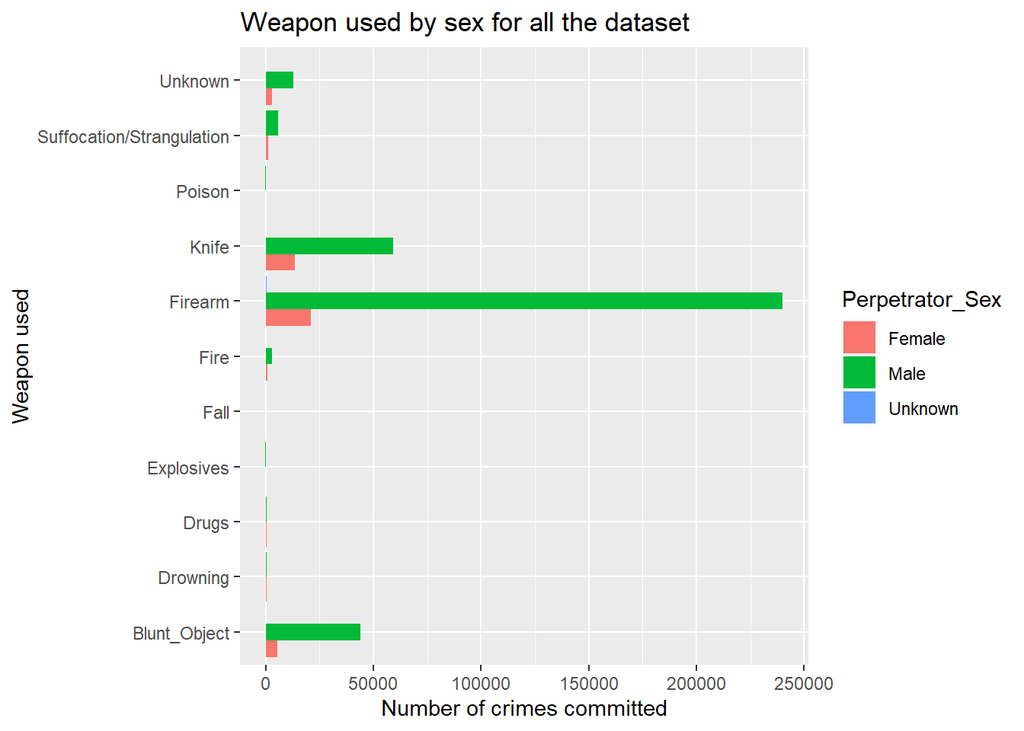

**Observations of Weapons of Choice**

## Elderly (90+) Perpetrators - Victims Age

Victims Age of Elderly Perpetrators

| Perpetrator_Age_Group | Victim_Age_Group | Num_VGroup |
| --- | --- | --- |
| 90 and over | 90 and over | 4309 |

**Observations of Victims Age**

## Elderly (90+) Perpetrators - Perpetrators Sex

Sex of Elderly Perpetrators

| Perpetrator_Age_Group | Perpetrator_Sex | Victim_Age_Group | Weapon | Count |
| --- | --- | --- | --- | --- |
| 90 and over | Male | 90 and over | Firearm | 1877 |
| 90 and over | Male | 90 and over | Blunt_Object | 694 |
| 90 and over | Male | 90 and over | Knife | 541 |
| 90 and over | Male | 90 and over | Unknown | 342 |
| 90 and over | Female | 90 and over | Blunt_Object | 197 |
| 90 and over | Female | 90 and over | Firearm | 161 |
| 90 and over | Female | 90 and over | Unknown | 132 |

**Observations of Perpetrators Sex**

## Pre-Teen / Teen Perpetrators (10-19) - Teen Adults

Teens Adults

| Perpetrator_Age | n |
| --- | --- |
| 18 | 18411 |
| 19 | 19846 |

**Observations of Teens Adults**

## Pre-Teen / Teen Perpetrators (10-19) - Weapons of Choice

Weapons of Choice by Pre-Teen / Teen Perpetrators

| Perpetrator_Age_Group | Weapon | Num_Weapons | Proportion |
| --- | --- | --- | --- |
| 10-19 | Firearm | 36821 | 0.7575246 |
| 10-19 | Knife | 6738 | 0.1386220 |
| 10-19 | Blunt_Object | 2524 | 0.0519267 |
| 10-19 | Unknown | 1309 | 0.0269303 |
| 10-19 | Suffocation/Strangulation | 616 | 0.0126731 |
| 10-19 | Fire | 368 | 0.0075709 |
| 10-19 | Drugs | 115 | 0.0023659 |

**Observations of Weapons of Choice**

## Pre-Teen / Teen Perpetrators (10-19) - Victims Age

Victims Age of Pre-Teen / Teen Perpetrators

| Perpetrator_Age_Group | Victim_Age_Group | Num_VGroup |
| --- | --- | --- |
| 10-19 | 10-19 | 48607 |

**Observations of Victims Age**

## Pre-Teen / Teen Perpetrators (10-19) - Perpetrators Sex

Sex of Pre-Teen / Teen Perpetrators

| Perpetrator_Age_Group | Perpetrator_Sex | Victim_Age_Group | Weapon | Count |
| --- | --- | --- | --- | --- |
| 10-19 | Male | 10-19 | Firearm | 35549 |
| 10-19 | Male | 10-19 | Knife | 5929 |
| 10-19 | Male | 10-19 | Blunt_Object | 2416 |
| 10-19 | Female | 10-19 | Firearm | 1219 |
| 10-19 | Male | 10-19 | Unknown | 1176 |
| 10-19 | Female | 10-19 | Knife | 805 |
| 10-19 | Male | 10-19 | Suffocation/Strangulation | 563 |
| 10-19 | Male | 10-19 | Fire | 295 |

**Observations of Perpetrators Sex**

# Modeling

## Random Forest to Predict Perpetrator’s Race

A Random Forest model was created to predict a perpetrator’s race based on state, month, perpetrator sex, perpetrator age, weapon, victim sex, victim age, victim race, and relationship. The hypothesis is that the perpetrator’s race is very closely related to the victim’s race.

As a side note, the ntree = 100 is set for faster run time.

Important Variables

| Variable | MeanDecreaseAccuracy |
| --- | --- |
| Victim_Race | 727.69343 |
| Relationship | 137.32808 |
| Perpetrator_Age | 101.79489 |
| Victim_Age | 88.89276 |
| Weapon | 83.29065 |
| State | 80.80018 |
| Perpetrator_Sex | 68.48416 |
| Victim_Sex | 44.03357 |
| Month | 16.83546 |

**Observations of Random Forest Model - Important Variables**

Error Details

| Perpetrator_Race | Count | Wrong | Error_rate | Overall_error_rate |
| --- | --- | --- | --- | --- |
| Asian/Pacific_Islander | 1129 | 476 | 0.4216120 | 0.1275187 |
| Black | 39093 | 5276 | 0.1349602 | 0.1275187 |
| Native_American/Alaska_Native | 705 | 365 | 0.5177305 | 0.1275187 |
| Unknown | 718 | 420 | 0.5849582 | 0.1275187 |
| White | 40986 | 4000 | 0.0975943 | 0.1275187 |

Confusion Matrix

|  | Asian/Pacific_Islander | Black | Native_American/Alaska_Native | Unknown | White |
| --- | --- | --- | --- | --- | --- |
| Asian/Pacific_Islander | 653 | 136 | 3 | 7 | 330 |
| Black | 75 | 33819 | 29 | 57 | 5113 |
| Native_American/Alaska_Native | 2 | 47 | 341 | 2 | 313 |
| Unknown | 21 | 135 | 5 | 297 | 260 |
| White | 193 | 3614 | 109 | 82 | 36988 |

**Observations of Random Forest Model - Error Rate and Confusion Matrix**

1. The Error Rate of the model is approximately 0.13.
2. The model is most accurate when Perpetrator_Race = White or Black.
3. The model is least accurate when Perpetrator_Race = Asian/Pacific_Islander, Native_American/Alaska_Native, or Unknown.

Initially, the relative age (Victim - Perp) is assessed to see if there a pattern. The California data is being used for this analysis.

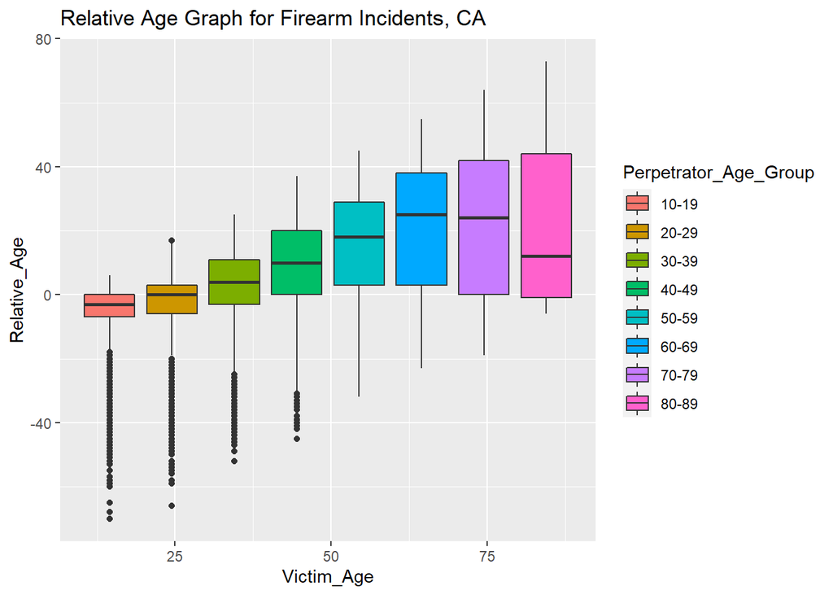

As observed, up to the age of 40, the victim and perpetrator are very similar in age. The median of each of those groups is almost equal to 0. The older they get the higher the relative age gets; this means that older victims tend to be targeted by individuals younger than they are. One possible interpretation would be that as the pool of potential victims gets older it is difficult to be targeted by someone even older than them, which would lead to a positive relative age. Furthermore, the spread from the boxplot graph gets wider the further we move up the age range. The last age group is mostly outliers as data is sparse and does not follow the same pattern as the rest.

**Linear Model**

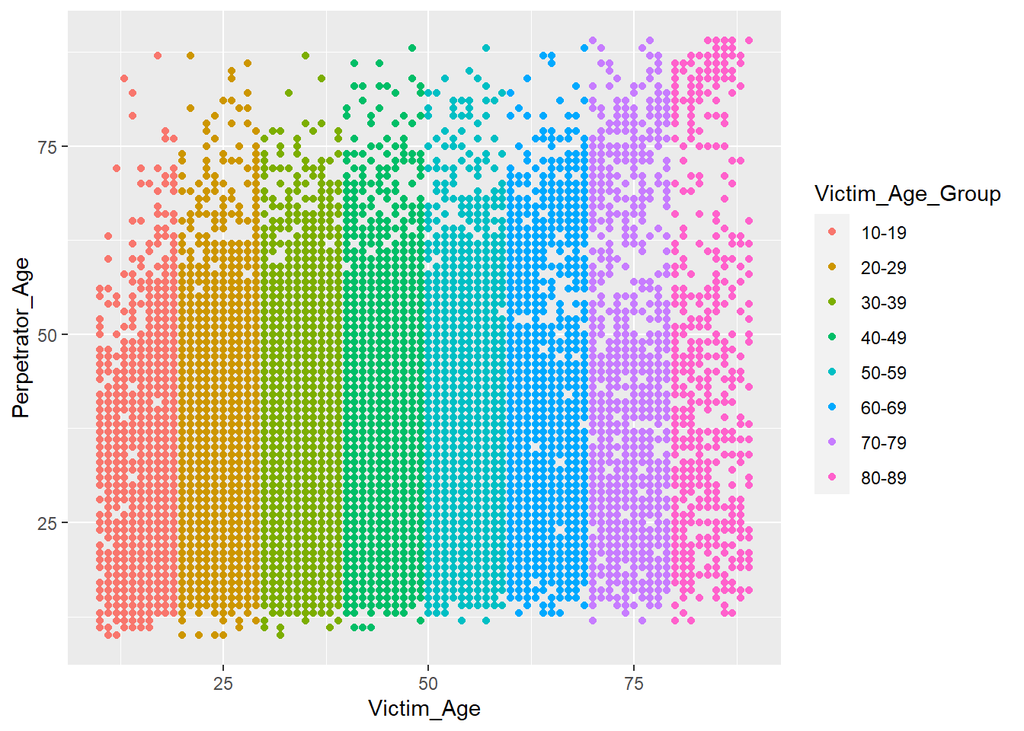

**Observations of Age Groups Data - Scatter Plot**

1. The Scatter Plot shows the Perpetrator Age by Victim Age relationship for each Victim Age Group.
2. The data looks scattered but you can see a small sign of linear relationship between the two variables. This relationship is not sufficiently clear because there are so many outliers within each Victim groups. To see a clearer linear trend would mean to remove the outliers.

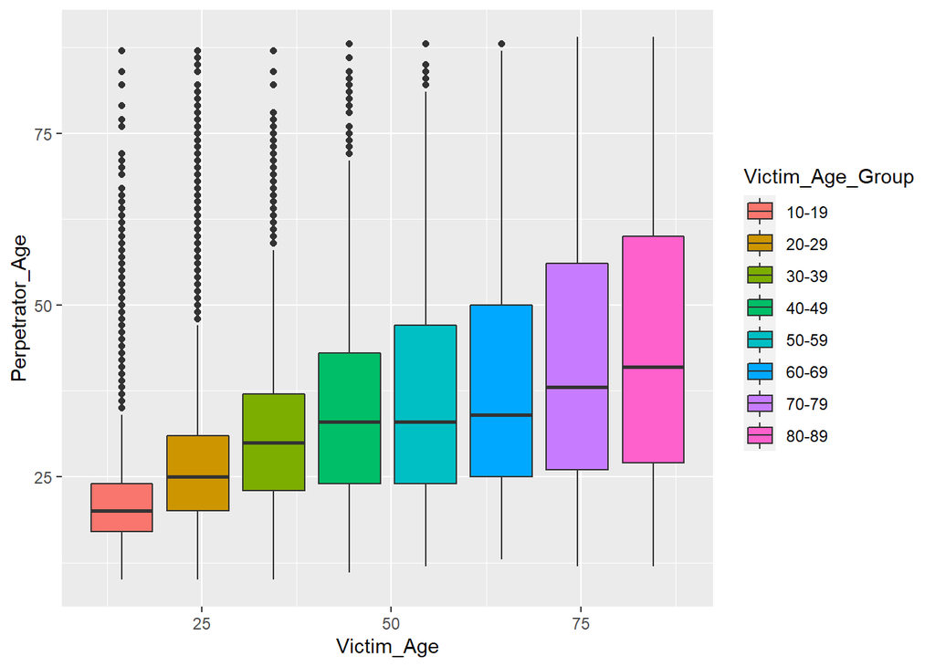

**Observations of Age Groups Data - Box Plot**

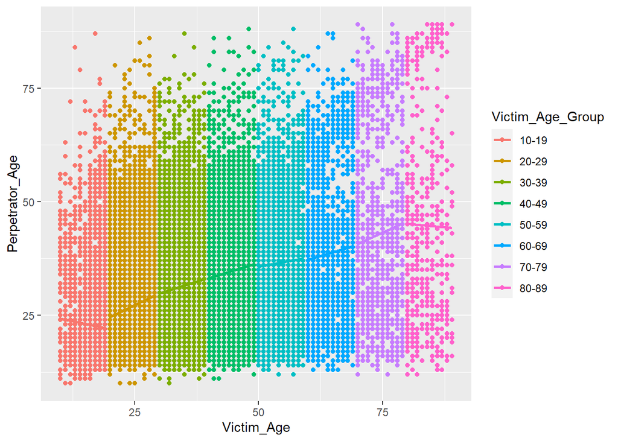

**Observations of Linear Regression Model**

Since the baseline was removed and the interaction in the linear model included, different slopes for each Victim_Age_Group were obtained. As Perpetrator_Age increases, Victim_Age increases as well. However, many of Victim_Age values outside of the slope of predicted values still exist. This is because Homicide is motivated by a large number of factors making the victim somewhat random, even taking relationship, ages, etc. into account. However, between each Perpetrator_Age_Group there is still a linear pattern between ages of Perpetrators and Victims.

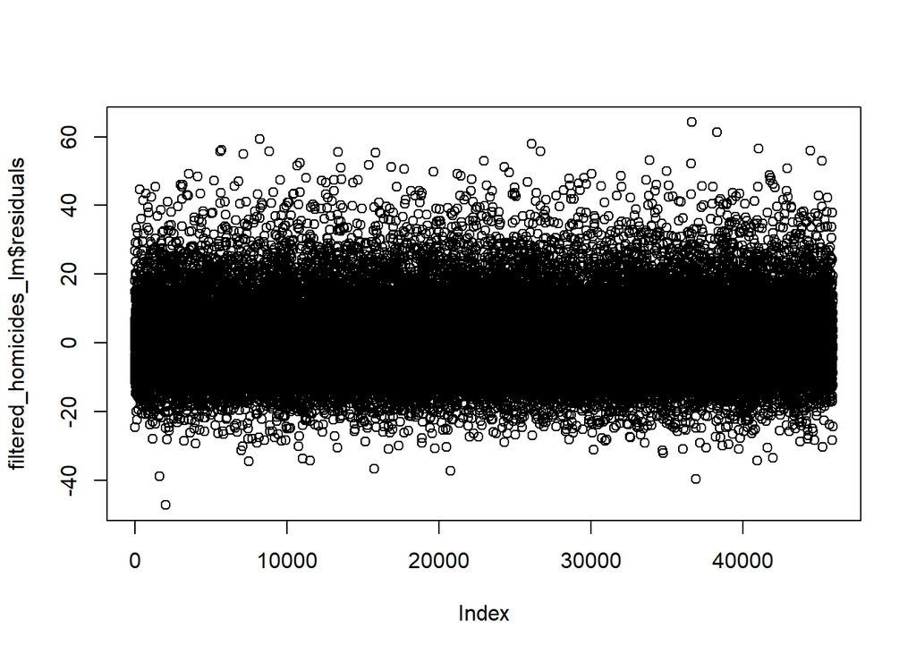

**Observations of Linear Regression Model Residuals**

A good way to test the accuracy or fit of the model is to look at the residuals or the differences between the real values and the predicted values. The idea here is that the sum of the residuals is approximately zero or close to it as possible. Ideally, when you plot the residuals, they should look random. Otherwise, there might be a hidden pattern that the linear model is not considering.

# Summary

# Conclusion

Using different analysis methods many different patterns and insights about the homicides in the United States were extracted and observed. The hypothesis was that perpetrators are usually the same race and similar age to that of the victim. Given the analysis conducted, the conclusion is that in an unsolved murder, the perpetrator is likely to be male, of the same race, and similar age group to the victim.